# Analysis of Sussex County property data by subdivision

In this excercise, I take subdivision level property data and try to answer the following questions:

1. In which subdivisions are houses selling the fastest? Selling slowest?
2. In which subdivisions is the median sale price improving most? Dropping most?
3. Where can a seller get the best deal in terms of median sale price / median list price

## Methodology

To tackle these questions, I'm using [Pandas](http://pandas.pydata.org/) - a Python library for data analysis - and [SciPy](http://docs.scipy.org/doc/scipy-0.13.0/reference/index.html) - a mathematics, science and engineering library - to filter, group and ultimately run a [ordinary least squares linear regression](http://en.wikipedia.org/wiki/Ordinary_least_squares) to determine the positive or negative movement on a number of variables.

## About the data

The town/ZIP code level data comes from the InnoVia MLS and provided by the Sussex County Association of Realtors. Unfortunately, the provided data does not include all of the fields that were used in similar anayses for the other two counties. Specifically, we are missing `Median DOM`, `Median Sale Price/Original Listing Price` and `Median Sale Price/Final Listing Price`. We do have a Median Sale Price/Median Final Listing Price for each area - a much more genralized figure than the other measures: Here is the basic structure of our data:

- Subdivision
  - The name of the subdivision
- Year
  - The data year
- Sales
  - Number of transactions
  - (Note this doesn't necessarily mean number of homes)
- Median Sale Price
  - Median price of transactions
- Avg. Sale Price
  - Average price of transactions
- Avg. Days on Market
  - Average number of days the house was listed for sale.
- Median Sale Price / Median Listing Price
  - The ratio between the median sale price for the total area and the median listing price for the total area.
  - A value above 1.0 means the median sale price for the area was above the median listing price.

## Known Issues

There are three issues that directly affect this analysis:

1. We do not have data for the entire county. The Sussex County Association of Realtors was only able to provide us with data for the beach communities and select communities in the western part of the county; 25 communities in total. The reasoning, we were told, is that there system is quite limited and they were only able to pull out data for one community at a time (ouch).
2. Averages. Unlike data for the other counties, we only have `Average DOM`.
3. The figures we have for Sale Price vs. Listing Price are at the area level, not the transaction level. It's simply the median sale price for the entire area divided by the median listing price for the entire area.

## Preparing the data

```python
# General Imports
import matplotlib.pyplot as plt
import pandas as pd
from scipy.stats import linregress
import re
# Enable inline plotting
%matplotlib inline
```

```python
# import the data into a Pandas dataframe.
df = pd.read_csv('Sussex Home Sales.csv')
print "Original Data:"
print df.info()
print "="*100

# Filter out data where the subdivision is "None Available."
df = df[df.Subdiv != 'None Available']

# Get the total number of subdivisions
orig_subdiv_count = len(df.Subdiv.unique())

# Filter out data where there are less than 5 sales
df = df[df.Sales >= 5]

# Filter out the subdivisions that don't have 4 years
# worth of data.
df = df.groupby('Subdiv').filter(lambda x: x.count() >= 3)

# Get the number of subdivisions that survived the cuts
new_subdiv_count = len(df.Subdiv.unique())

# R-SQUARED THRESHOLD
R2_THRESHOLD = 0.5

# Set the Subdivision as the Index.
df = df.set_index(['Subdiv'])
print "Filtered Data:"
df.info()

# Group by the subdivisions for use in our calculations below
by_subdivision = df.groupby(df.index)
```

```
Original Data:
<class 'pandas.core.frame.DataFrame'>
Int64Index: 99 entries, 0 to 98
Data columns (total 7 columns):
Subdiv                99 non-null object
Year                  99 non-null int64
Sales                 99 non-null int64
Median Sold Price     99 non-null int64
Average Sold Price    99 non-null int64
Average DOM           99 non-null int64
Median SP/LP          99 non-null float64
dtypes: float64(1), int64(5), object(1)None
====================================================================================================
Filtered Data:
<class 'pandas.core.frame.DataFrame'>
Index: 78 entries, Bridgeville 19933 to SOUTH BETHANY - West of Rt. 1
Data columns (total 6 columns):
Year                  78 non-null int64
Sales                 78 non-null int64
Median Sold Price     78 non-null int64
Average Sold Price    78 non-null int64
Average DOM           78 non-null int64
Median SP/LP          78 non-null float64
dtypes: float64(1), int64(5)
```

```python
print "Examining %d of %d subdivisions (%.2f percent)" % (new_subdiv_count, orig_subdiv_count, ( float(new_subdiv_count) / orig_subdiv_count * 100 ))
```

```
Examining 20 of 25 subdivisions (80.00 percent)
```

```python
# Integrity Check: Top # of property sales.
# This should be Outside Lewes.
most_sales = df.sort(['Sales'], ascending=[0])
print "**Subdivisions with the most sales:"
most_sales.head(5)[['Year', 'Sales']]
```

```
**Subdivisions with the most sales:
```

| Subdiv | Year | Sales |
| --- | --- | --- |
| Outside Lewes - West of Route 1 | 2013 | 306 |
| Outside Lewes - West of Route 1 | 2012 | 240 |
| Seaford/Blades 19973 | 2013 | 210 |
| Seaford/Blades 19973 | 2012 | 198 |
| Outside Lewes - West of Route 1 | 2011 | 191 |

5 rows × 2 columns

```python
# Integrity Check: Dewey Beach (2010) should be the top
shortest_dom = df.sort(['Average DOM'], ascending=[1])
print "**Subdivisions with the shortest median DOM:"
shortest_dom.head(7)[['Year', 'Average DOM', 'Sales']]
```

```
**Subdivisions with the shortest median DOM:
```

| Subdiv | Year | Average DOM | Sales |
| --- | --- | --- | --- |
| DEWEY BEACH | 2010 | 86 | 9 |
| Delmar 19940 | 2010 | 88 | 24 |
| Outside Lewes - East of Rt. 1 | 2013 | 89 | 120 |
| Delmar 19940 | 2013 | 96 | 32 |
| SOUTH BETHANY - East of Rt. 1 | 2010 | 122 | 6 |
| Delmar 19940 | 2011 | 128 | 28 |
| Outside Lewes - West of Route 1 | 2011 | 136 | 191 |

7 rows × 3 columns

### Examining issues with number of sales

Due to the larger areas used in this analysis , we don't run into many of the problems with area/year combos with only a few sales.

```
The most popular Subdivision/Year:
```

| Subdiv | Year | Sales | Median Sold Price | Average Sold Price | Average DOM | Median SP/LP |
| --- | --- | --- | --- | --- | --- | --- |
| Outside Lewes - West of Route 1 | 2013 | 306 | 329900 | 339284 | 156 | 1.016055 |

1 rows × 6 columns

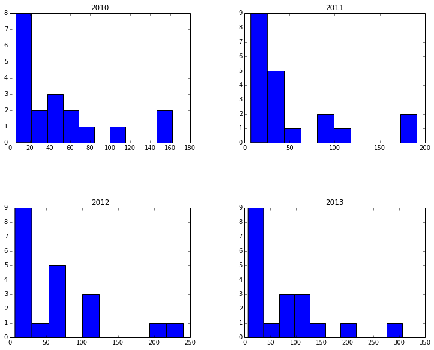

```python
# Plot Subdivisions by number of sales.
df['Sales'].hist(by=df.Year, bins=10, figsize=(12,10))
print "The most popular Subdivision/Year:"
df[df['Sales'] == df['Sales'].max()]
```

### How does DOM compare to other factors?

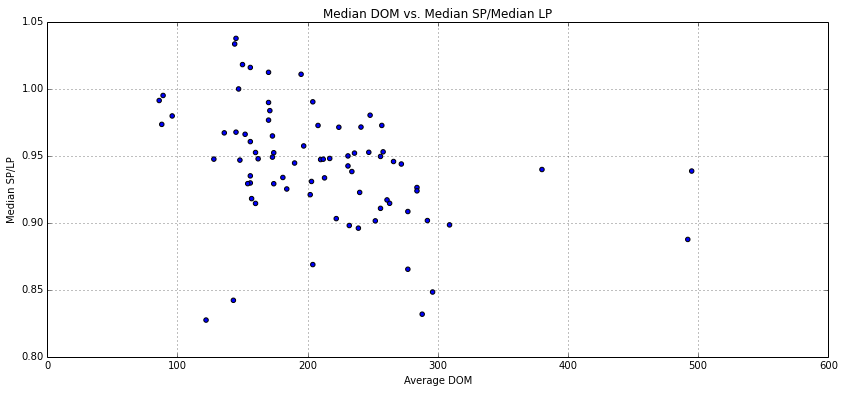

```python
df.plot(
    x="Average DOM",
    y="Median SP/LP",
    kind='scatter',
    title="Median DOM vs. Median SP/Median LP",
    figsize=[14,6])
```

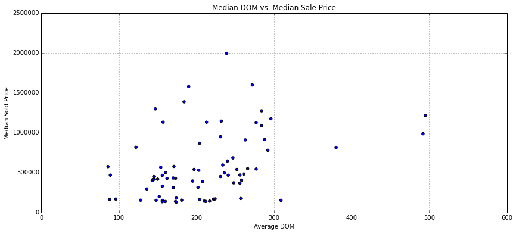

```python
df.plot(
    x="Average DOM",
    y="Median Sold Price",
    kind='scatter',
    title="Median DOM vs. Median Sale Price",
    figsize=[14,6])
```

```
Median DOM by year:
```

```
array([[<matplotlib.axes.AxesSubplot object at 0x112d26710>,
        <matplotlib.axes.AxesSubplot object at 0x112c65290>]], dtype=object)
```

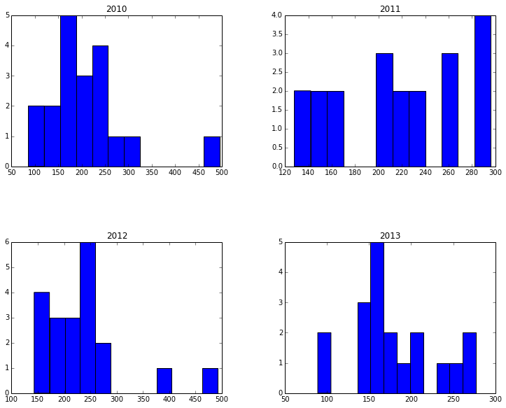

```python
print "Median DOM by year:"
df['Average DOM'].hist(by=df.Year, bins=12, figsize=[12,10])
```

```
SP/LP by year
```

```
array([[<matplotlib.axes.AxesSubplot object at 0x112c7b8d0>,
        <matplotlib.axes.AxesSubplot object at 0x1132a3750>]], dtype=object)
```

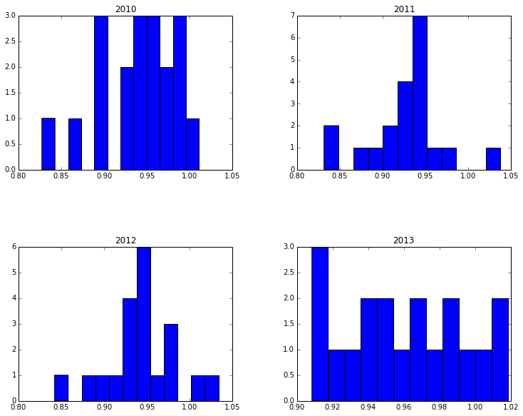

```python
print "SP/LP by year"
df['Median SP/LP'].hist(by=df.Year, bins=12, figsize=[12,10])
```

```
SP/LP For All Years
```

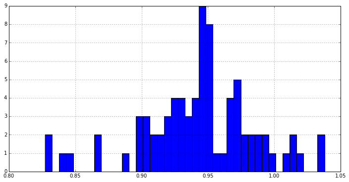

```python
print "SP/LP For All Years"
df['Median SP/LP'].hist(bins=40, figsize=[12,6])
```

# 1. In which subdivisions are houses selling the fastest? Selling slowest?

Grouping our data by subdivision, we are able to run each through a linear regression with SciPy's `linregress` function.

Back to top

```python
def calculateSlope(df, attribute, r_squared_threshold=R2_THRESHOLD):
    """Gets the slope of an attribute of the dataframe along with
    min, max and r-squared values."""
    # Using scipy's linregress, get the slope of dom/year for each subdivision
    slope = pd.DataFrame(df.apply(lambda x: linregress(y=x[attribute], x=x.Year)[0]))
    r2 = pd.DataFrame(df.apply(lambda x: linregress(y=x[attribute], x=x.Year)[2]**2))
    output = pd.merge(left=slope, right=r2, left_index=True, right_index=True)

    # Get the max and min DOM for each subdivision.
    output = pd.merge(left=output, right=pd.DataFrame(df[attribute].min()), left_index=True, right_index=True)
    output = pd.merge(left=output, right=pd.DataFrame(df[attribute].max()), left_index=True, right_index=True)
    output= pd.merge(left=output, right=pd.DataFrame(df['Sales'].sum()), left_index=True, right_index=True)

    # Fix Column names
    attribute = re.sub(r'[\W]+', '_', attribute).lower()
    output.columns = [attribute+'_slope', attribute+'_r2', attribute+'_min', attribute+'_max', 'sales_count']

    return output, output[output[attribute+'_r2'] >= r_squared_threshold]
```

```
array([[<matplotlib.axes.AxesSubplot object at 0x113292390>,
        <matplotlib.axes.AxesSubplot object at 0x11357b5d0>]], dtype=object)
```

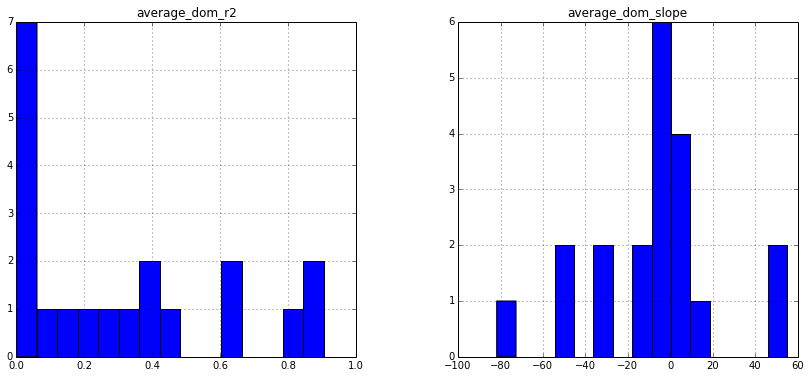

```python
average_dom, average_dom_adj = calculateSlope(by_subdivision, 'Average DOM')
average_dom[['average_dom_slope', 'average_dom_r2']].hist(bins=15, figsize=[14,6])
```

```python
print "The best fit:"
average_dom[average_dom.average_dom_r2 == average_dom.average_dom_r2.max()]
```

```
The best fit:
```

| Subdiv | average_dom_slope | average_dom_r2 | average_dom_min | average_dom_max | sales_count |
| --- | --- | --- | --- | --- | --- |
| Outside Lewes - East of Rt. 1 | -31.9 | 0.904582 | 89 | 195 | 274 |

1 rows × 5 columns

```python
print "The Worst fit:"
average_dom[average_dom.average_dom_r2 == average_dom.average_dom_r2.min()]
```

```
The Worst fit:
```

| Subdiv | average_dom_slope | average_dom_r2 | average_dom_min | average_dom_max | sales_count |
| --- | --- | --- | --- | --- | --- |
| BETHANY - West of Rt. 1 | -0.4 | 0.000087 | 160 | 258 | 219 |

1 rows × 5 columns

### The top and bottom five for DOM

```python
print "TOP 5:"
average_dom.sort(['average_dom_slope']).head(5)
```

```
TOP 5:
```

| Subdiv | average_dom_slope | average_dom_r2 | average_dom_min | average_dom_max | sales_count |
| --- | --- | --- | --- | --- | --- |
| BETHANY - East of Rt. 1 | -81.8 | 0.413274 | 157 | 495 | 61 |
| Bridgeville 19933 | -46.7 | 0.619967 | 152 | 309 | 194 |
| SOUTH REHOBOTH | -46.5 | 0.848290 | 147 | 288 | 74 |
| REHOBOTH West Rt 1 | -34.2 | 0.830356 | 150 | 256 | 451 |
| Outside Lewes - East of Rt. 1 | -31.9 | 0.904582 | 89 | 195 | 274 |

5 rows × 5 columns

```python
print "TOP 5 (adjusted for better R^2 values):"
average_dom_adj.sort(['average_dom_slope']).head(5)
```

```
TOP 5 (adjusted for better R^2 values):
```

| Subdiv | average_dom_slope | average_dom_r2 | average_dom_min | average_dom_max | sales_count |
| --- | --- | --- | --- | --- | --- |
| Bridgeville 19933 | -46.7 | 0.619967 | 152 | 309 | 194 |
| SOUTH REHOBOTH | -46.5 | 0.848290 | 147 | 288 | 74 |
| REHOBOTH West Rt 1 | -34.2 | 0.830356 | 150 | 256 | 451 |
| Outside Lewes - East of Rt. 1 | -31.9 | 0.904582 | 89 | 195 | 274 |
| DEWEY BEACH | 46.6 | 0.636672 | 86 | 261 | 60 |

5 rows × 5 columns

```python
print "Bottom 5:"
average_dom.sort(['average_dom_slope'], ascending=False).head(5)
```

```
Bottom 5:
```

| Subdiv | average_dom_slope | average_dom_r2 | average_dom_min | average_dom_max | sales_count |
| --- | --- | --- | --- | --- | --- |
| SOUTH BETHANY - East of Rt. 1 | 55.0 | 0.442165 | 122 | 284 | 20 |
| DEWEY BEACH | 46.6 | 0.636672 | 86 | 261 | 60 |
| NORTH REHOBOTH | 17.6 | 0.416232 | 204 | 284 | 76 |
| Delmar 19940 | 6.9 | 0.053294 | 88 | 173 | 118 |
| Seaford/Blades 19973 | 6.4 | 0.269120 | 181 | 217 | 735 |

5 rows × 5 columns

```python
print "Bottom 5 (adjusted for better R^2 values):"
average_dom_adj.sort(['average_dom_slope'], ascending=False).head(5)
```

```
Bottom 5 (adjusted for better R^2 values):
```

| Subdiv | average_dom_slope | average_dom_r2 | average_dom_min | average_dom_max | sales_count |
| --- | --- | --- | --- | --- | --- |
| DEWEY BEACH | 46.6 | 0.636672 | 86 | 261 | 60 |
| Outside Lewes - East of Rt. 1 | -31.9 | 0.904582 | 89 | 195 | 274 |
| REHOBOTH West Rt 1 | -34.2 | 0.830356 | 150 | 256 | 451 |
| SOUTH REHOBOTH | -46.5 | 0.848290 | 147 | 288 | 74 |
| Bridgeville 19933 | -46.7 | 0.619967 | 152 | 309 | 194 |

5 rows × 5 columns

### Close look at top and bottom DOM subdivisions

#### The top subdivisions (both normal and R^2 corrected)

```python
df[df.index == average_dom[average_dom.average_dom_slope == average_dom.average_dom_slope.min()].index]
```

| Subdiv | Year | Sales | Median Sold Price | Average Sold Price | Average DOM | Median SP/LP |
| --- | --- | --- | --- | --- | --- | --- |
| BETHANY - East of Rt. 1 | 2013 | 12 | 1132500 | 1220125 | 157 | 0.918119 |
| BETHANY - East of Rt. 1 | 2012 | 22 | 987500 | 1076614 | 492 | 0.887640 |
| BETHANY - East of Rt. 1 | 2011 | 13 | 1175000 | 1290908 | 296 | 0.848375 |
| BETHANY - East of Rt. 1 | 2010 | 14 | 1217500 | 1196786 | 495 | 0.938705 |

4 rows × 6 columns

```python
df[df.index == average_dom[average_dom.average_dom_slope == average_dom_adj.average_dom_slope.min()].index]
```

| Subdiv | Year | Sales | Median Sold Price | Average Sold Price | Average DOM | Median SP/LP |
| --- | --- | --- | --- | --- | --- | --- |
| Bridgeville 19933 | 2010 | 32 | 152250 | 164041 | 309 | 0.898495 |
| Bridgeville 19933 | 2011 | 40 | 151000 | 166382 | 156 | 0.929803 |
| Bridgeville 19933 | 2012 | 54 | 137500 | 149664 | 160 | 0.914533 |
| Bridgeville 19933 | 2013 | 68 | 199750 | 183530 | 152 | 0.966166 |

4 rows × 6 columns

#### The bottom subdivisions (both normal and R^2 corrected)

```python
df[df.index == average_dom[average_dom.average_dom_slope == average_dom.average_dom_slope.max()].index]
```

| Subdiv | Year | Sales | Median Sold Price | Average Sold Price | Average DOM | Median SP/LP |
| --- | --- | --- | --- | --- | --- | --- |
| SOUTH BETHANY - East of Rt. 1 | 2012 | 7 | 1145000 | 1281700 | 232 | 0.898039 |
| SOUTH BETHANY - East of Rt. 1 | 2011 | 7 | 1275000 | 1200714 | 284 | 0.923913 |
| SOUTH BETHANY - East of Rt. 1 | 2010 | 6 | 817500 | 1056667 | 122 | 0.827429 |

3 rows × 6 columns

```python
df[df.index == average_dom[average_dom.average_dom_slope == average_dom_adj.average_dom_slope.max()].index]
```

| Subdiv | Year | Sales | Median Sold Price | Average Sold Price | Average DOM | Median SP/LP |
| --- | --- | --- | --- | --- | --- | --- |
| DEWEY BEACH | 2013 | 13 | 481500 | 867558 | 261 | 0.917143 |
| DEWEY BEACH | 2012 | 18 | 400000 | 693624 | 143 | 0.842194 |
| DEWEY BEACH | 2011 | 20 | 315000 | 700340 | 202 | 0.921053 |
| DEWEY BEACH | 2010 | 9 | 575000 | 714000 | 86 | 0.991379 |

4 rows × 6 columns

# 2. In which subdivisions is the median sale price improving most? Dropping most?

Back to top

```
array([[<matplotlib.axes.AxesSubplot object at 0x11331dc10>,
        <matplotlib.axes.AxesSubplot object at 0x1138407d0>]], dtype=object)
```

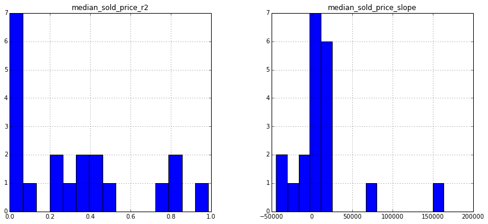

```python
median_saleprice, median_saleprice_adj = calculateSlope(by_subdivision, 'Median Sold Price')

median_saleprice[['median_sold_price_r2', 'median_sold_price_slope']].hist(bins=15, figsize=[14,6])
```

```python
print "The best fit:"
median_saleprice[median_saleprice.median_sold_price_r2 == median_saleprice.median_sold_price_r2.max()]
```

```
The best fit:
```

| Subdiv | median_sold_price_slope | median_sold_price_r2 | median_sold_price_min | median_sold_price_max | sales_count |
| --- | --- | --- | --- | --- | --- |
| Georgetown 19947 | 4410 | 0.986137 | 167000 | 180000 | 371 |

1 rows × 5 columns

```python
print "The Worst fit:"
median_saleprice[median_saleprice.median_sold_price_r2 == median_saleprice.median_sold_price_r2.min()]
```

```
The Worst fit:
```

| Subdiv | median_sold_price_slope | median_sold_price_r2 | median_sold_price_min | median_sold_price_max | sales_count |
| --- | --- | --- | --- | --- | --- |
| Delmar 19940 | 95 | 0.000087 | 137450 | 167750 | 118 |

1 rows × 5 columns

### The top and bottom 5 for median saleprice

```python
print "TOP 5:"
median_saleprice.sort(['median_sold_price_slope'], ascending=False).head(5)
```

```
TOP 5:
```

| Subdiv | median_sold_price_slope | median_sold_price_r2 | median_sold_price_min | median_sold_price_max | sales_count |
| --- | --- | --- | --- | --- | --- |
| SOUTH BETHANY - East of Rt. 1 | 163750.0 | 0.482466 | 817500 | 1275000 | 20 |
| SOUTH REHOBOTH | 73900.0 | 0.367933 | 915000 | 1299000 | 74 |
| Outside Lewes - East of Rt. 1 | 21851.3 | 0.806850 | 393722 | 467116 | 274 |
| NORTH BETHANY - East of Rt. 1 | 18375.0 | 0.008698 | 1387500 | 1993750 | 53 |
| REHOBOTH West Rt 1 | 15915.8 | 0.819627 | 367500 | 417361 | 451 |

5 rows × 5 columns

```python
print "TOP 5 (adjusted for R-squared)"
median_saleprice_adj.sort(['median_sold_price_slope'], ascending=False).head(5)
```

```
TOP 5 (adjusted for R-squared)
```

| Subdiv | median_sold_price_slope | median_sold_price_r2 | median_sold_price_min | median_sold_price_max | sales_count |
| --- | --- | --- | --- | --- | --- |
| Outside Lewes - East of Rt. 1 | 21851.3 | 0.806850 | 393722 | 467116 | 274 |
| REHOBOTH West Rt 1 | 15915.8 | 0.819627 | 367500 | 417361 | 451 |
| Georgetown 19947 | 4410.0 | 0.986137 | 167000 | 180000 | 371 |
| Laurel 19956 | -6330.0 | 0.751741 | 130000 | 151500 | 393 |

4 rows × 5 columns

```python
print "BOTTOM 5:"
median_saleprice.sort(['median_sold_price_slope']).head(5)
```

```
BOTTOM 5:
```

| Subdiv | median_sold_price_slope | median_sold_price_r2 | median_sold_price_min | median_sold_price_max | sales_count |
| --- | --- | --- | --- | --- | --- |
| BETHANY - East of Rt. 1 | -44250.0 | 0.326565 | 987500 | 1217500 | 61 |
| Lewes - East of Canal | -40275.0 | 0.443256 | 595750 | 780000 | 71 |
| DEWEY BEACH | -19550.0 | 0.051455 | 315000 | 575000 | 60 |
| SOUTH BETHANY - West of Rt. 1 | -10276.6 | 0.199161 | 495000 | 566875 | 65 |
| Laurel 19956 | -6330.0 | 0.751741 | 130000 | 151500 | 393 |

5 rows × 5 columns

```python
print "BOTTOM 5 (adjusted for better R-squared):"
median_saleprice_adj.sort(['median_sold_price_slope']).head(5)
```

```
BOTTOM 5 (adjusted for better R-squared):
```

| Subdiv | median_sold_price_slope | median_sold_price_r2 | median_sold_price_min | median_sold_price_max | sales_count |
| --- | --- | --- | --- | --- | --- |
| Laurel 19956 | -6330.0 | 0.751741 | 130000 | 151500 | 393 |
| Georgetown 19947 | 4410.0 | 0.986137 | 167000 | 180000 | 371 |
| REHOBOTH West Rt 1 | 15915.8 | 0.819627 | 367500 | 417361 | 451 |
| Outside Lewes - East of Rt. 1 | 21851.3 | 0.806850 | 393722 | 467116 | 274 |

4 rows × 5 columns

### Close look at the top and bottom subdivisions by change in median saleprice

#### The top subdivisions (both normal and R2 adjusted)

```python
df[df.index == median_saleprice[median_saleprice.median_sold_price_slope == median_saleprice.median_sold_price_slope.max()].index]
```

| Subdiv | Year | Sales | Median Sold Price | Average Sold Price | Average DOM | Median SP/LP |
| --- | --- | --- | --- | --- | --- | --- |
| SOUTH BETHANY - East of Rt. 1 | 2012 | 7 | 1145000 | 1281700 | 232 | 0.898039 |
| SOUTH BETHANY - East of Rt. 1 | 2011 | 7 | 1275000 | 1200714 | 284 | 0.923913 |
| SOUTH BETHANY - East of Rt. 1 | 2010 | 6 | 817500 | 1056667 | 122 | 0.827429 |

3 rows × 6 columns

```python
df[df.index == median_saleprice[median_saleprice.median_sold_price_slope == median_saleprice_adj.median_sold_price_slope.max()].index]
```

| Subdiv | Year | Sales | Median Sold Price | Average Sold Price | Average DOM | Median SP/LP |
| --- | --- | --- | --- | --- | --- | --- |
| Outside Lewes - East of Rt. 1 | 2013 | 120 | 467116 | 495000 | 89 | 0.995143 |
| Outside Lewes - East of Rt. 1 | 2012 | 67 | 413331 | 435842 | 144 | 1.033586 |
| Outside Lewes - East of Rt. 1 | 2011 | 41 | 415000 | 457030 | 145 | 1.037759 |
| Outside Lewes - East of Rt. 1 | 2010 | 46 | 393722 | 406887 | 195 | 1.010969 |

4 rows × 6 columns

#### The bottom subdivisions (both normal and r-squared adjusted)

```python
df[df.index == median_saleprice[median_saleprice.median_sold_price_slope == median_saleprice.median_sold_price_slope.min()].index]
```

| Subdiv | Year | Sales | Median Sold Price | Average Sold Price | Average DOM | Median SP/LP |
| --- | --- | --- | --- | --- | --- | --- |
| BETHANY - East of Rt. 1 | 2013 | 12 | 1132500 | 1220125 | 157 | 0.918119 |
| BETHANY - East of Rt. 1 | 2012 | 22 | 987500 | 1076614 | 492 | 0.887640 |
| BETHANY - East of Rt. 1 | 2011 | 13 | 1175000 | 1290908 | 296 | 0.848375 |
| BETHANY - East of Rt. 1 | 2010 | 14 | 1217500 | 1196786 | 495 | 0.938705 |

4 rows × 6 columns

```python
df[df.index == median_saleprice[median_saleprice.median_sold_price_slope == median_saleprice_adj.median_sold_price_slope.min()].index]
```

| Subdiv | Year | Sales | Median Sold Price | Average Sold Price | Average DOM | Median SP/LP |
| --- | --- | --- | --- | --- | --- | --- |
| Laurel 19956 | 2010 | 65 | 151500 | 151101 | 148 | 0.946875 |
| Laurel 19956 | 2011 | 85 | 142000 | 152563 | 210 | 0.947298 |
| Laurel 19956 | 2012 | 121 | 130000 | 129077 | 174 | 0.929235 |
| Laurel 19956 | 2013 | 122 | 134400 | 137943 | 156 | 0.960686 |

4 rows × 6 columns

# 3. Where can a seller get the best deal in terms of median sale price / median listing price?

Back to top

```
array([[<matplotlib.axes.AxesSubplot object at 0x11384ba50>,
        <matplotlib.axes.AxesSubplot object at 0x1138d5510>]], dtype=object)
```

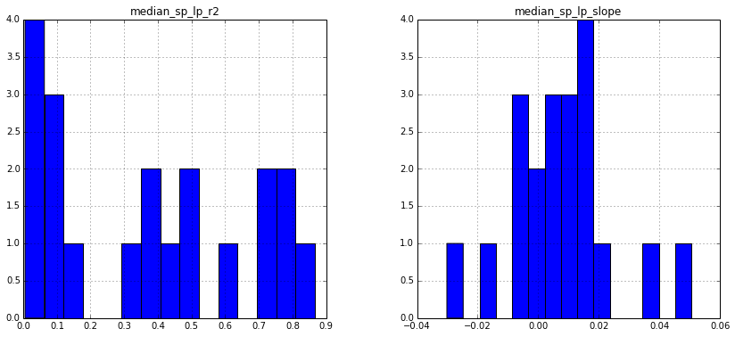

```python
lp, lp_adj = calculateSlope(by_subdivision, 'Median SP/LP')

lp[['median_sp_lp_r2', 'median_sp_lp_slope']].hist(bins=15, figsize=[14,6])
```

```python
print "The best fit:"
lp[lp.median_sp_lp_r2 == lp.median_sp_lp_r2.max()]
```

```
The best fit:
```

| Subdiv | median_sp_lp_slope | median_sp_lp_r2 | median_sp_lp_min | median_sp_lp_max | sales_count |
| --- | --- | --- | --- | --- | --- |
| FENWICK ISLAND - West of Rt. 1 | -0.018673 | 0.866541 | 0.908485 | 0.94583 | 29 |

1 rows × 5 columns

```python
print "The Worst fit:"
lp[lp.median_sp_lp_r2 == lp.median_sp_lp_r2.min()]
```

```
The Worst fit:
```

| Subdiv | median_sp_lp_slope | median_sp_lp_r2 | median_sp_lp_min | median_sp_lp_max | sales_count |
| --- | --- | --- | --- | --- | --- |
| BETHANY - East of Rt. 1 | -0.002249 | 0.005461 | 0.848375 | 0.938705 | 61 |

1 rows × 5 columns

### The top and bottom 5 for sp/olp

```python
print "TOP 5:"
lp.sort(['median_sp_lp_slope'], ascending=False).head(5)
```

```
TOP 5:
```

| Subdiv | median_sp_lp_slope | median_sp_lp_r2 | median_sp_lp_min | median_sp_lp_max | sales_count |
| --- | --- | --- | --- | --- | --- |
| SOUTH REHOBOTH | 0.050564 | 0.763682 | 0.831818 | 1.000000 | 74 |
| SOUTH BETHANY - East of Rt. 1 | 0.035305 | 0.499765 | 0.827429 | 0.923913 | 20 |
| Bridgeville 19933 | 0.018774 | 0.702263 | 0.898495 | 0.966166 | 194 |
| Seaford/Blades 19973 | 0.016896 | 0.792497 | 0.933899 | 0.990400 | 735 |
| Outside Lewes - West of Route 1 | 0.016320 | 0.724178 | 0.967213 | 1.016055 | 899 |

5 rows × 5 columns

```python
print "TOP 5 (adjusted for better r-squared):"
lp_adj.sort(['median_sp_lp_slope'], ascending=False).head(5)
```

```
TOP 5 (adjusted for better r-squared):
```

| Subdiv | median_sp_lp_slope | median_sp_lp_r2 | median_sp_lp_min | median_sp_lp_max | sales_count |
| --- | --- | --- | --- | --- | --- |
| SOUTH REHOBOTH | 0.050564 | 0.763682 | 0.831818 | 1.000000 | 74 |
| Bridgeville 19933 | 0.018774 | 0.702263 | 0.898495 | 0.966166 | 194 |
| Seaford/Blades 19973 | 0.016896 | 0.792497 | 0.933899 | 0.990400 | 735 |
| Outside Lewes - West of Route 1 | 0.016320 | 0.724178 | 0.967213 | 1.016055 | 899 |
| REHOBOTH East Rt 1 Other | 0.010815 | 0.612731 | 0.942507 | 0.983816 | 212 |

5 rows × 5 columns

```python
print "BOTTOM 5:"
lp.sort(['median_sp_lp_slope']).head(5)
```

```
BOTTOM 5:
```

| Subdiv | median_sp_lp_slope | median_sp_lp_r2 | median_sp_lp_min | median_sp_lp_max | sales_count |
| --- | --- | --- | --- | --- | --- |
| DEWEY BEACH | -0.030157 | 0.408142 | 0.842194 | 0.991379 | 60 |
| FENWICK ISLAND - West of Rt. 1 | -0.018673 | 0.866541 | 0.908485 | 0.945830 | 29 |
| Lewes - West of Canal | -0.005250 | 0.081457 | 0.935111 | 0.989904 | 217 |
| Outside Lewes - East of Rt. 1 | -0.005165 | 0.111374 | 0.995143 | 1.037759 | 274 |
| NORTH REHOBOTH | -0.004861 | 0.033912 | 0.868869 | 0.950001 | 76 |

5 rows × 5 columns

```python
print "BOTTOM 5 (adjusted for better r-squared):"
lp_adj.sort(['median_sp_lp_slope']).head(5)
```

```
BOTTOM 5 (adjusted for better r-squared):
```

| Subdiv | median_sp_lp_slope | median_sp_lp_r2 | median_sp_lp_min | median_sp_lp_max | sales_count |
| --- | --- | --- | --- | --- | --- |
| FENWICK ISLAND - West of Rt. 1 | -0.018673 | 0.866541 | 0.908485 | 0.945830 | 29 |
| REHOBOTH East Rt 1 Other | 0.010815 | 0.612731 | 0.942507 | 0.983816 | 212 |
| Outside Lewes - West of Route 1 | 0.016320 | 0.724178 | 0.967213 | 1.016055 | 899 |
| Seaford/Blades 19973 | 0.016896 | 0.792497 | 0.933899 | 0.990400 | 735 |
| Bridgeville 19933 | 0.018774 | 0.702263 | 0.898495 | 0.966166 | 194 |

5 rows × 5 columns

### Close look at the top and bottom subdivisions by sp/olp

#### Top subdivisions

```python
df[df.index == lp[lp.median_sp_lp_slope == lp.median_sp_lp_slope.max()].index]
```

| Subdiv | Year | Sales | Median Sold Price | Average Sold Price | Average DOM | Median SP/LP |
| --- | --- | --- | --- | --- | --- | --- |
| SOUTH REHOBOTH | 2013 | 17 | 1299000 | 1343588 | 147 | 1.000000 |
| SOUTH REHOBOTH | 2012 | 22 | 1132000 | 1469200 | 213 | 0.933608 |
| SOUTH REHOBOTH | 2011 | 15 | 915000 | 1269900 | 288 | 0.831818 |
| SOUTH REHOBOTH | 2010 | 20 | 1125000 | 1432892 | 277 | 0.865385 |

4 rows × 6 columns

```python
df[df.index == lp[lp.median_sp_lp_slope == lp_adj.median_sp_lp_slope.max()].index]
```

| Subdiv | Year | Sales | Median Sold Price | Average Sold Price | Average DOM | Median SP/LP |
| --- | --- | --- | --- | --- | --- | --- |
| SOUTH REHOBOTH | 2013 | 17 | 1299000 | 1343588 | 147 | 1.000000 |
| SOUTH REHOBOTH | 2012 | 22 | 1132000 | 1469200 | 213 | 0.933608 |
| SOUTH REHOBOTH | 2011 | 15 | 915000 | 1269900 | 288 | 0.831818 |
| SOUTH REHOBOTH | 2010 | 20 | 1125000 | 1432892 | 277 | 0.865385 |

4 rows × 6 columns

#### The bottom subdivisions

```python
df[df.index == lp[lp.median_sp_lp_slope == lp.median_sp_lp_slope.min()].index]
```

| Subdiv | Year | Sales | Median Sold Price | Average Sold Price | Average DOM | Median SP/LP |
| --- | --- | --- | --- | --- | --- | --- |
| DEWEY BEACH | 2013 | 13 | 481500 | 867558 | 261 | 0.917143 |
| DEWEY BEACH | 2012 | 18 | 400000 | 693624 | 143 | 0.842194 |
| DEWEY BEACH | 2011 | 20 | 315000 | 700340 | 202 | 0.921053 |
| DEWEY BEACH | 2010 | 9 | 575000 | 714000 | 86 | 0.991379 |

4 rows × 6 columns

```python
df[df.index == lp[lp.median_sp_lp_slope == lp_adj.median_sp_lp_slope.min()].index]
```

| Subdiv | Year | Sales | Median Sold Price | Average Sold Price | Average DOM | Median SP/LP |
| --- | --- | --- | --- | --- | --- | --- |
| FENWICK ISLAND - West of Rt. 1 | 2013 | 7 | 545000 | 556566 | 277 | 0.908485 |
| FENWICK ISLAND - West of Rt. 1 | 2012 | 8 | 812500 | 806312 | 380 | 0.939850 |
| FENWICK ISLAND - West of Rt. 1 | 2011 | 14 | 550000 | 695100 | 266 | 0.945830 |

3 rows × 6 columns

### Throwing it all together for output to csv

```python
# Combine all of our stats into a single dataframe.
merge_out = pd.merge(
    left=average_dom[['sales_count','average_dom_slope', 'average_dom_r2', 'average_dom_min', 'average_dom_max']],
    right=median_saleprice[['median_sold_price_slope', 'median_sold_price_r2', 'median_sold_price_min', 'median_sold_price_max']],
    left_index=True,
    right_index=True)
merge_out = pd.merge(
    left=merge_out,
    right=lp[['median_sp_lp_slope', 'median_sp_lp_r2', 'median_sp_lp_min', 'median_sp_lp_max']],
    left_index=True,
    right_index=True)

# Add the rankings for each.
merge_out['dom_slope_rank'] = merge_out['average_dom_slope'].rank(ascending=True)
merge_out['median_price_rank'] = merge_out['median_sold_price_slope'].rank(ascending=False)
merge_out['sp_lp_rank'] = merge_out['median_sp_lp_slope'].rank(ascending=False)
merge_out['average_rank'] = merge_out[['dom_slope_rank', 'median_price_rank', 'sp_lp_rank']].mean(axis=1)
print "The Top Ten"
print merge_out.sort('average_rank')[['average_rank']].head(10)


merge_out.sort('average_rank').to_csv('data_out_sco.txt', sep='\t')
```

```
The Top Ten
                                 average_rank
Subdiv
SOUTH REHOBOTH                       2.000000
Bridgeville 19933                    4.000000
REHOBOTH West Rt 1                   5.333333
SOUTH BETHANY - East of Rt. 1        7.666667
Georgetown 19947                     7.666667
REHOBOTH East Rt 1 Other             8.333333
Outside Lewes - East of Rt. 1        8.333333
Outside Lewes - West of Route 1      9.000000
NORTH BETHANY - East of Rt. 1        9.333333
BETHANY - West of Rt. 1             10.000000

[10 rows x 1 columns]
```

Click here to download the final data.